# 대학원신입생과제_Rbasic

예지혜 / 학번 212STG18

2021년 2월 14일

##### 1. Final 점수가 midterm보다 작고, midterm 점수가 80 보다 큰 학생을 찾으시오.

```r
students <- c("Sean", "Louisa", "Frank", "Farhad", "Li")
midterm <- c(80, 90, 93, 82, 95)
final <- c(78, 84, 95, 82, 91) # Final exam scores
names(midterm)<-students->names(final)
# ans
students[(final < midterm) & (midterm > 80)]
```

```
## [1] "Louisa" "Li"
```

##### 2. subset 함수를 이용하여, survey에서 Program 값이 “PPM”이거나 “Other”이면서 Rexperience가 “Basic competence”인 경우, 변수 “OperatingSystem”, “TVhours”를 출력하시오.

```r
survey <- read.table("http://www.andrew.cmu.edu/user/achoulde/94842/data/survey_data.csv", header=TRUE, sep=",")
# ans
subset(survey,
       select = c("OperatingSystem", "TVhours"),
       subset = (Program == "PPM" | Program == "Other") &
         (Rexperience == "Basic competence")
)
```

```
##    OperatingSystem TVhours
## 3         Mac OS X      16
## 4         Mac OS X       0
## 7         Mac OS X       0
## 8          Windows       4
## 9          Windows       0
## 15        Mac OS X       4
## 17        Mac OS X      10
## 21         Windows       8
## 23         Windows       0
## 24         Windows       0
## 25         Windows       0
## 27        Mac OS X       6
```

##### 3. Cars93 데이터에서 변수, AirBags과 Origin의 frequency table을 만드시오.

```r
library(MASS)
data(Cars93)
head(Cars93, 3)
```

```
##   Manufacturer   Model    Type Min.Price Price Max.Price MPG.city
## 1        Acura Integra   Small      12.9  15.9      18.8       25
## 2        Acura  Legend Midsize      29.2  33.9      38.7       18
## 3         Audi      90 Compact      25.9  29.1      32.3       20
##   MPG.highway            AirBags DriveTrain Cylinders EngineSize
## 1          31               None      Front         4        1.8
## 2          25 Driver & Passenger      Front         6        3.2
## 3          26        Driver only      Front         6        2.8
##   Horsepower  RPM Rev.per.mile Man.trans.avail Fuel.tank.capacity
## 1        140 6300         2890             Yes               13.2
## 2        200 5500         2335             Yes               18.0
## 3        172 5500         2280             Yes               16.9
##   Passengers Length Wheelbase Width Turn.circle Rear.seat.room
## 1          5    177       102    68          37           26.5
## 2          5    195       115    71          38           30.0
## 3          5    180       102    67          37           28.0
##   Luggage.room Weight  Origin          Make
## 1           11   2705 non-USA Acura Integra
## 2           15   3560 non-USA  Acura Legend
## 3           14   3375 non-USA       Audi 90
```

```r
# ans
table(Cars93$AirBags, Cars93$Origin)
```

```
##
##                      USA non-USA
##   Driver & Passenger   9       7
##   Driver only         23      20
##   None                16      18
```

##### 4. Cars93 데이터의 Origin과 Type의 horsepower mean table을 만드시오. [Hint: tapply() 함수 이용.]

```r
tapply(Cars93[["Horsepower"]], INDEX = Cars93[c("Origin", "Type")], FUN=mean)
```

```
##          Type
## Origin     Compact    Large  Midsize    Small   Sporty    Van
##   USA     117.4286 179.4545 153.5000 89.42857 166.5000 158.40
##   non-USA 141.5556       NA 189.4167 91.78571 151.6667 138.25
```

##### 5. MASS 패키지에 있는 birthwt 데이터의 변수명을 다음과 같이 바꾸고 다음 문제를 푸시오.

```r
library(MASS)
library(ggplot2)
library(plyr)
data(birthwt)
colnames(birthwt) <- c("birthwt.below.2500", "mother.age", "mother.weight",
                       "race", "mother.smokes", "previous.prem.labor", "hypertension", "uterine.irr",
                       "physician.visits", "birthwt.grams")
birthwt <- transform(birthwt,
                     race = as.factor(mapvalues(race, c(1, 2, 3), c("white","black", "other"))),
                     mother.smokes = as.factor(mapvalues(mother.smokes, c(0,1), c("no", "yes"))),
                     hypertension = as.factor(mapvalues(hypertension, c(0,1), c("no", "yes"))),
                     uterine.irr = as.factor(mapvalues(uterine.irr, c(0,1), c("no", "yes"))),
                     birthwt.below.2500 = as.factor(mapvalues(birthwt.below.2500, c(0,1), c("no", "yes")))
)
head(birthwt,3)
```

```
##    birthwt.below.2500 mother.age mother.weight  race mother.smokes
## 85                 no         19           182 black            no
## 86                 no         33           155 other            no
## 87                 no         20           105 white           yes
##    previous.prem.labor hypertension uterine.irr physician.visits
## 85                   0           no         yes                0
## 86                   0           no          no                3
## 87                   0           no          no                1
##    birthwt.grams
## 85          2523
## 86          2551
## 87          2557
```

##### (1) aggregate() 함수를 이용하여 race와 mother.smokes의 각 경우(race 3가지* mother.smokes 2가지 = 6가지 경우)에 해당하는 birthwt.grams의 평균을 보여주는 data frame을 만드시오.

```r
aggregate(birthwt.grams ~ race + mother.smokes, FUN=mean, data=birthwt)
```

```
##    race mother.smokes birthwt.grams
## 1 black            no      2854.500
## 2 other            no      2815.782
## 3 white            no      3428.750
## 4 black           yes      2504.000
## 5 other           yes      2757.167
## 6 white           yes      2826.846
```

##### (2) ggplot을 이용하여 x축은 mother.age로 하고, y축은 birthwt.grams로 하여 plot을 만드시오. 각 관측치는 mothe.smokes를 색깔과 shape을 달리 구분하여 점으로 표시하시오.

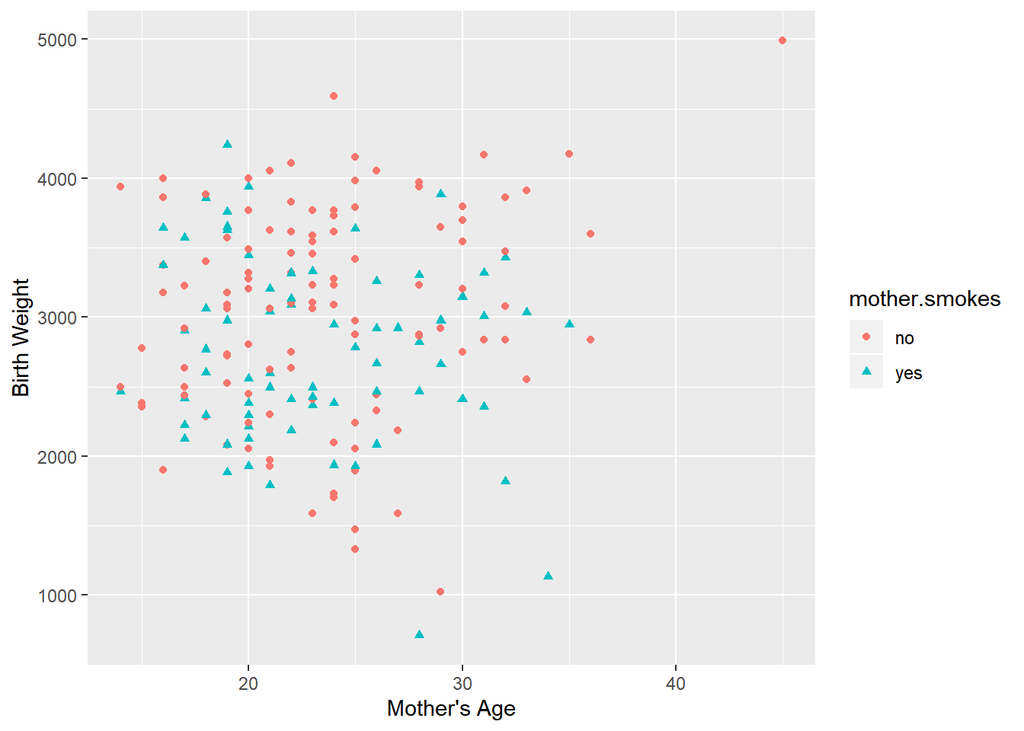

```r
ggplot(birthwt, aes(x=mother.age, y=birthwt.grams, shape=mother.smokes, color=mother.smokes)) +
  geom_point() +
  ylab("Birth Weight") +
  xlab("Mother's Age")
```

##### 6. ggplot을 이용하여 Lecture6에 있는 plot 아무거나 하나만 그리고, 설명하시오.

```r
library(maps)
arrests <- USArrests
names(arrests) <- tolower(names(arrests))
arrests$region <- tolower(rownames(USArrests))
head(arrests)
```

```
##            murder assault urbanpop rape     region
## Alabama      13.2     236       58 21.2    alabama
## Alaska       10.0     263       48 44.5     alaska
## Arizona       8.1     294       80 31.0    arizona
## Arkansas      8.8     190       50 19.5   arkansas
## California    9.0     276       91 40.6 california
## Colorado      7.9     204       78 38.7   colorado
```

```r
states <- map_data("state")
head(states)
```

```
##        long      lat group order  region subregion
## 1 -87.46201 30.38968     1     1 alabama      <NA>
## 2 -87.48493 30.37249     1     2 alabama      <NA>
## 3 -87.52503 30.37249     1     3 alabama      <NA>
## 4 -87.53076 30.33239     1     4 alabama      <NA>
## 5 -87.57087 30.32665     1     5 alabama      <NA>
## 6 -87.58806 30.32665     1     6 alabama      <NA>
```

```r
choro <- merge(states, arrests, sort = FALSE, by = "region")
choro <- choro[order(choro$order), ]
head(choro)
```

```
##    region      long      lat group order subregion murder assault urbanpop
## 1 alabama -87.46201 30.38968     1     1      <NA>   13.2     236       58
## 2 alabama -87.48493 30.37249     1     2      <NA>   13.2     236       58
## 6 alabama -87.52503 30.37249     1     3      <NA>   13.2     236       58
## 7 alabama -87.53076 30.33239     1     4      <NA>   13.2     236       58
## 8 alabama -87.57087 30.32665     1     5      <NA>   13.2     236       58
## 9 alabama -87.58806 30.32665     1     6      <NA>   13.2     236       58
##   rape
## 1 21.2
## 2 21.2
## 6 21.2
## 7 21.2
## 8 21.2
## 9 21.2
```

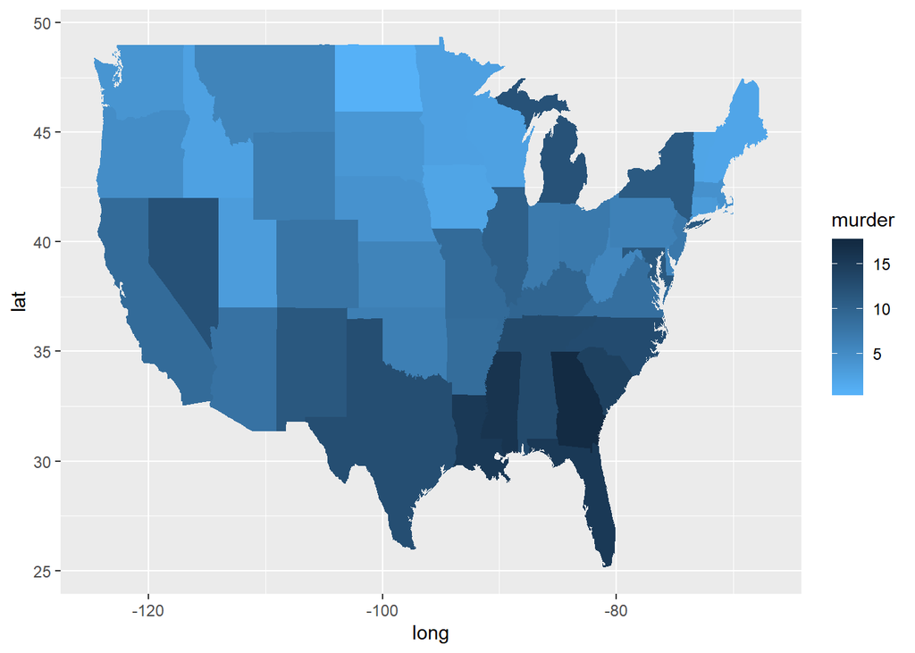

```r
qplot(long, lat, data = choro, group = group, fill = murder, geom = "polygon") + scale_fill_gradient(low = "#56B1F7", high = "#132B43")
```

미국의 주별 살인사건 발생 건수에 대한 데이터 USArrests에 위치 데이터 states를 merge하여 지도그래프를 그렸다. geom = “polygon” 옵션을 통해 주별 경계의 위도, 경도 값을 이용해 다각형을 그렸고, 살인사건 발생 건수인 murder의 크기만큼 색칠하였다. 단, scale_fill_gradient() 명령을 통해 큰 값을 가질수록 진하게 색칠되도록 표현하였다.

##### 7. t-test를 이용하여 mother.smokes의 두 집단간 birthwt.grams의 차이가 있는지 양측 검정하시오.

```r
birthwt.t.test <- t.test(birthwt.grams ~ mother.smokes, data = birthwt)
birthwt.t.test
```

```
##
##  Welch Two Sample t-test
##
## data:  birthwt.grams by mother.smokes
## t = 2.7299, df = 170.1, p-value = 0.007003
## alternative hypothesis: true difference in means is not equal to 0
## 95 percent confidence interval:
##   78.57486 488.97860
## sample estimates:
##  mean in group no mean in group yes
##          3055.696          2771.919
```

p-value가 0.05보다 작으므로 유의수준 0.05에서 귀무가설을 기각하며, 두 집단 간에 birthwt.grams의 차이가 있다.

##### 8. mother.smokes가 no인 경우에 birthwt.grams 값에 대해서 normal 분포의 qqplot을 그리시오.

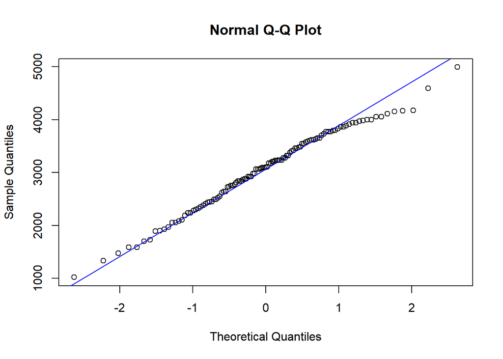

```r
with(birthwt, qqnorm(birthwt.grams[mother.smokes=="no"]))
with(birthwt, qqline(birthwt.grams[mother.smokes=="no"], col = "blue"))
```

##### 9. 다음 crime 데이터에서 y를 crime.per.million로 하고, x는 exp.per.cap.1959와 unemp.youth를 제외한 모든 변수를 포함시켜 선형 회귀분석을 하시오.

```r
crime <- read.table("http://www.andrew.cmu.edu/user/achoulde/94842/data/crime_simple.txt", sep = "\t", header = TRUE)
colnames(crime) <- c("crime.per.million", "young.males", "is.south", "average.ed",
                     "exp.per.cap.1960", "exp.per.cap.1959", "labour.part",
                     "male.per.fem", "population", "nonwhite",
                     "unemp.youth", "unemp.adult", "median.assets", "num.low.salary")

head(crime,3)
```

```
##   crime.per.million young.males is.south average.ed exp.per.cap.1960
## 1              79.1         151        1         91               58
## 2             163.5         143        0        113              103
## 3              57.8         142        1         89               45
##   exp.per.cap.1959 labour.part male.per.fem population nonwhite
## 1               56         510          950         33      301
## 2               95         583         1012         13      102
## 3               44         533          969         18      219
##   unemp.youth unemp.adult median.assets num.low.salary
## 1         108          41           394            261
## 2          96          36           557            194
## 3          94          33           318            250
```

```r
# ans
crime.lm <- lm(crime.per.million ~ .- exp.per.cap.1959 - unemp.youth, data = crime)
summary(crime.lm)
```

```
##
## Call:
## lm(formula = crime.per.million ~ . - exp.per.cap.1959 - unemp.youth,
##     data = crime)
##
## Residuals:
##    Min     1Q Median     3Q    Max
## -35.82 -11.57  -1.51  10.63  55.02
##
## Coefficients:
##                    Estimate Std. Error t value Pr(>|t|)
## (Intercept)      -6.334e+02  1.455e+02  -4.354 0.000111 ***
## young.males       1.127e+00  4.188e-01   2.691 0.010853 *
## is.south         -5.566e-01  1.388e+01  -0.040 0.968248
## average.ed        1.533e+00  6.203e-01   2.471 0.018476 *
## exp.per.cap.1960  1.138e+00  2.270e-01   5.015 1.53e-05 ***
## labour.part       6.872e-02  1.335e-01   0.515 0.610087
## male.per.fem      3.021e-03  1.730e-01   0.017 0.986172
## population       -6.448e-02  1.283e-01  -0.503 0.618367
## nonwhite         -1.379e-02  6.190e-02  -0.223 0.824960
## unemp.adult       9.315e-01  5.418e-01   1.719 0.094402 .
## median.assets     1.516e-01  1.052e-01   1.440 0.158653
## num.low.salary    8.259e-01  2.342e-01   3.527 0.001197 **
## ---
## Signif. codes:  0 '***' 0.001 '**' 0.01 '*' 0.05 '.' 0.1 ' ' 1
##
## Residual standard error: 21.98 on 35 degrees of freedom
## Multiple R-squared:  0.7543, Adjusted R-squared:  0.6771
## F-statistic: 9.769 on 11 and 35 DF,  p-value: 9.378e-08
```

##### 10. 9번의 회귀분석 summary를 R markdown에서 kable 함수를 이용하여 나타내시오.

```r
library(knitr)
crime.lm.summary <- summary(crime.lm)
kable(crime.lm.summary$coef, digits = c(3, 3, 3, 4), format = 'markdown')
```

|  | Estimate | Std. Error | t value | Pr(>\|t\|) |
| --- | --- | --- | --- | --- |
| (Intercept) | -633.439 | 145.470 | -4.354 | 0.0001 |
| young.males | 1.127 | 0.419 | 2.691 | 0.0109 |
| is.south | -0.557 | 13.883 | -0.040 | 0.9682 |
| average.ed | 1.533 | 0.620 | 2.471 | 0.0185 |
| exp.per.cap.1960 | 1.138 | 0.227 | 5.015 | 0.0000 |
| labour.part | 0.069 | 0.134 | 0.515 | 0.6101 |
| male.per.fem | 0.003 | 0.173 | 0.017 | 0.9862 |
| population | -0.064 | 0.128 | -0.503 | 0.6184 |
| nonwhite | -0.014 | 0.062 | -0.223 | 0.8250 |
| unemp.adult | 0.931 | 0.542 | 1.719 | 0.0944 |
| median.assets | 0.152 | 0.105 | 1.440 | 0.1587 |
| num.low.salary | 0.826 | 0.234 | 3.527 | 0.0012 |

##### 11. qgplot을 이용하여 Lecture11에 있는 plot 아무거나 하나만 그리고, 설명하시오.

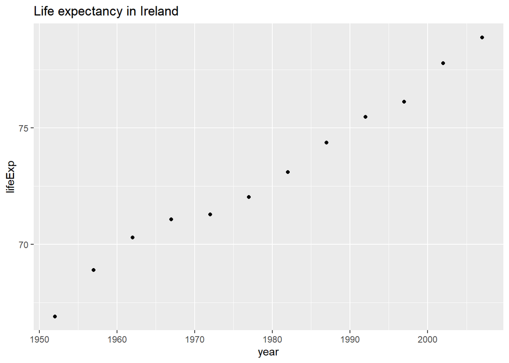

```r
gapminder <- read.delim("http://www.andrew.cmu.edu/user/achoulde/94842/data/gapminder_five_year.txt")
country.name <- "Ireland"
gapminder.sub <- subset(gapminder, country == country.name)
qplot(year, lifeExp, data = gapminder.sub, main = paste("Life expectancy in", country.name))
```

각국의 연도별 기대수명과 gdp 정보가 포함된 데이터 gapminder에서 Ireland의 정보만을 추출해 연도별 기대수명 산점도를 그려보았다. 제목은 paste 함수를 사용해 country.name에 다른 나라명을 넣더라도 plot의 제목이 연동되어 수정될 수 있도록 설정하였다.

##### 12. ggplot이나 qgplot을 이용하여 Lecture12에 있는 plot 아무거나 하나만 그리고, 설명하시오.

```r
year.min <- min(gapminder$year)
getCoef <- function(df) {
  coefs <- lm(lifeExp ~ I(year - year.min), data = df)$coef
  names(coefs) <- c("intercept", "slope")
  coefs
}
summary.coef <- ddply(gapminder, ~ country, getCoef)
summary.continent <- ddply(gapminder, ~ country, summarize, continent = unique(continent))
summary.merge <- merge(summary.coef, summary.continent, by = "country")
summary.intercept <- transform(summary.merge, country = reorder(country, intercept))
head(summary.intercept)
```

```
##       country intercept     slope continent
## 1 Afghanistan  29.90729 0.2753287      Asia
## 2     Albania  59.22913 0.3346832    Europe
## 3     Algeria  43.37497 0.5692797    Africa
## 4      Angola  32.12665 0.2093399    Africa
## 5   Argentina  62.68844 0.2317084  Americas
## 6   Australia  68.40051 0.2277238   Oceania
```

나라별 기대수명을 회귀분석하여 시각화해보았다. 회귀분석에서 slope과 coef를 가져오는 함수 getCoef를 정의한 후, 각 나라에 대해 ddply를 통해 적용시켰다. 이를 통해 각 나라의 회귀분석 결과와 대륙 정보를 가지는 summary.intercept라는 데이터셋을 생성하였다.

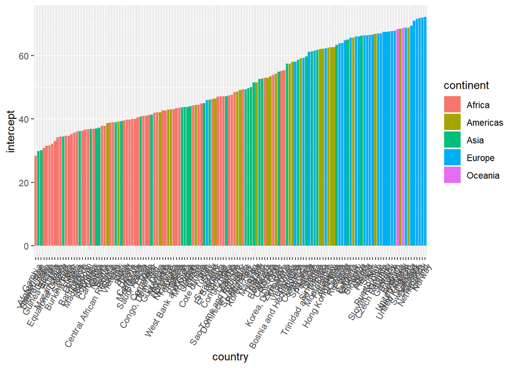

```r
intercept.fig <- ggplot(data = summary.intercept, mapping = aes(x = country, y = intercept, fill = continent))
intercept.fig + geom_bar(stat = "identity") +
  theme(axis.text.x = element_text(angle = 60, vjust = 1, hjust = 1))
```

생성한 데이터를 가지고, coef을 막대 높이로 하는 bar chart를 그려보았다. 각 나라가 위치한 대륙에 따라 막대의 색깔을 다르게 하였고, x축의 텍스트가 매우 긴 관계로, 각도를 조절하여 식별할 수 있게 하였다.

##### 13. dplyr 패키지의 piping을 이용하여 flights 데이터를 다음과 같은 순서로 manipulation하시오.

- year, month, day를 그룹핑한다.
- 변수 arr_delay, dep_delay를 선택한다.
- year, month, day의 각 그룹에 대해서 arr_delay의 평균을 구하고 변수 이름을 mean_arr_delay 이라고 한다.
- year, month, day의 각 그룹에 대해서 dep_delay의 평균을 구하고 변수 이름을 mean_dep_delay 이라고 한다.
- mean_arr_delay > 30 이거나 mean_dep_delay > 30인 경우만 filtering 한다.

```r
library(ggplot2)
library(dplyr)
library(nycflights13)
head(flights,3)
```

```
## # A tibble: 3 x 19
##    year month   day dep_time sched_dep_time dep_delay arr_time
##   <int> <int> <int>    <int>          <int>     <dbl>    <int>
## 1  2013     1     1      517            515         2      830
## 2  2013     1     1      533            529         4      850
## 3  2013     1     1      542            540         2      923
## # ... with 12 more variables: sched_arr_time <int>, arr_delay <dbl>,
## #   carrier <chr>, flight <int>, tailnum <chr>, origin <chr>, dest <chr>,
## #   air_time <dbl>, distance <dbl>, hour <dbl>, minute <dbl>,
## #   time_hour <dttm>
```

```r
# ans
flights %>%
  group_by(year, month, day) %>%
  select(arr_delay, dep_delay) %>%
  summarise(
    mean_arr_delay = mean(arr_delay, na.rm = TRUE),
    mean_dep_delay = mean(dep_delay, na.rm = TRUE)
  ) %>%
  filter(mean_arr_delay > 30 | mean_dep_delay > 30)
```

```
## # A tibble: 49 x 5
## # Groups:   year, month [11]
##     year month   day mean_arr_delay mean_dep_delay
##    <int> <int> <int>          <dbl>          <dbl>
##  1  2013     1    16           34.2           24.6
##  2  2013     1    31           32.6           28.7
##  3  2013     2    11           36.3           39.1
##  4  2013     2    27           31.3           37.8
##  5  2013     3     8           85.9           83.5
##  6  2013     3    18           41.3           30.1
##  7  2013     4    10           38.4           33.0
##  8  2013     4    12           36.0           34.8
##  9  2013     4    18           36.0           34.9
## 10  2013     4    19           47.9           46.1
## # ... with 39 more rows
```